# Navigation

In this notebook, you will learn how to use the Unity ML-Agents environment for the first project of the [Deep Reinforcement Learning Nanodegree](https://www.udacity.com/course/deep-reinforcement-learning-nanodegree--nd893).

### 1. Start the Environment

We begin by importing some necessary packages. If the code cell below returns an error, please revisit the project instructions to double-check that you have installed [Unity ML-Agents](https://github.com/Unity-Technologies/ml-agents/blob/master/docs/Installation.md) and [NumPy](http://www.numpy.org/).

```python
import torch
import numpy as np
from collections import deque
from unityagents import UnityEnvironment

import matplotlib.pyplot as plt
%matplotlib inline

# Watch for changes in any of the imported files
%load_ext autoreload
%autoreload 2
```

Next, we will start the environment! *Before running the code cell below*, change the `file_name` parameter to match the location of the Unity environment that you downloaded.

- **Mac**: `"path/to/Banana.app"`
- **Windows** (x86): `"path/to/Banana_Windows_x86/Banana.exe"`
- **Windows** (x86_64): `"path/to/Banana_Windows_x86_64/Banana.exe"`
- **Linux** (x86): `"path/to/Banana_Linux/Banana.x86"`
- **Linux** (x86_64): `"path/to/Banana_Linux/Banana.x86_64"`
- **Linux** (x86, headless): `"path/to/Banana_Linux_NoVis/Banana.x86"`
- **Linux** (x86_64, headless): `"path/to/Banana_Linux_NoVis/Banana.x86_64"`

For instance, if you are using a Mac, then you downloaded `Banana.app`. If this file is in the same folder as the notebook, then the line below should appear as follows:

```
env = UnityEnvironment(file_name="Banana.app")
```

```python
env = UnityEnvironment(file_name='./Banana.app') # `seed` is an optional param
```

```
INFO:unityagents:
'Academy' started successfully!
Unity Academy name: Academy
        Number of Brains: 1
        Number of External Brains : 1
        Lesson number : 0
        Reset Parameters :

Unity brain name: BananaBrain
        Number of Visual Observations (per agent): 0
        Vector Observation space type: continuous
        Vector Observation space size (per agent): 37
        Number of stacked Vector Observation: 1
        Vector Action space type: discrete
        Vector Action space size (per agent): 4
        Vector Action descriptions: , , ,
```

Environments contain *brains* which are responsible for deciding the actions of their associated agents. Here we check for the first brain available, and set it as the default brain we will be controlling from Python.

```python
# get the default brain
brain_name = env.brain_names[0]
brain = env.brains[brain_name]
```

### 2. Examine the State and Action Spaces

The simulation contains a single agent that navigates a large environment. At each time step, it has four actions at its disposal:

- `0` - walk forward
- `1` - walk backward
- `2` - turn left
- `3` - turn right

The state space has `37` dimensions and contains the agent's velocity, along with ray-based perception of objects around agent's forward direction. A reward of `+1` is provided for collecting a yellow banana, and a reward of `-1` is provided for collecting a blue banana.

Run the code cell below to print some information about the environment.

```python
# reset the environment
env_info = env.reset(train_mode=True)[brain_name]

# number of agents in the environment
print('Number of agents:', len(env_info.agents))

# number of actions
action_size = brain.vector_action_space_size
print('Number of actions:', action_size)

# examine the state space
state = env_info.vector_observations[0]
print('States look like:', state)
state_size = len(state)
print('States have length:', state_size)
```

```
Number of agents: 1
Number of actions: 4
States look like: [1.         0.         0.         0.         0.84408134 0.
 0.         1.         0.         0.0748472  0.         1.
 0.         0.         0.25755    1.         0.         0.
 0.         0.74177343 0.         1.         0.         0.
 0.25854847 0.         0.         1.         0.         0.09355672
 0.         1.         0.         0.         0.31969345 0.
 0.        ]
States have length: 37
```

### 3. Take Random Actions in the Environment

In the next code cell, you will learn how to use the Python API to control the agent and receive feedback from the environment.

Once this cell is executed, you will watch the agent's performance, if it selects an action (uniformly) at random with each time step. A window should pop up that allows you to observe the agent, as it moves through the environment.

Of course, as part of the project, you'll have to change the code so that the agent is able to use its experience to gradually choose better actions when interacting with the environment!

```python
env_info = env.reset(train_mode=False)[brain_name] # reset the environment
state = env_info.vector_observations[0]            # get the current state
score = 0                                          # initialize the score
while True:
    action = np.random.randint(action_size)        # select an action
    env_info = env.step(action)[brain_name]        # send the action to the environment
    next_state = env_info.vector_observations[0]   # get the next state
    reward = env_info.rewards[0]                   # get the reward
    done = env_info.local_done[0]                  # see if episode has finished
    score += reward                                # update the score
    state = next_state                             # roll over the state to next time step
    if done:                                       # exit loop if episode finished
        break

print("Score: {}".format(score))
```

```
Score: 0.0
```

When finished, you can close the environment.

```python
env.close()
```

### 4. It's Your Turn!

Now it's your turn to train your own agent to solve the environment! When training the environment, set `train_mode=True`, so that the line for resetting the environment looks like the following:

```
env_info = env.reset(train_mode=True)[brain_name]
```

The task is episodic, and in order to solve the environment, your agent must get an average score of +13 over 100 consecutive episodes.

```python
def plot_scores(scores):
    fig = plt.figure()
    ax = fig.add_subplot(111)
    plt.plot(np.arange(len(scores)), scores)
    plt.ylabel('Score')
    plt.xlabel('Episode #')
    plt.show()
```

```python
# Note: `brain_name` should be defined globally
def env_step(env, action):
    # Execute the action in the environment
    env_info = env.step(action)[brain_name]
    # Get the next state
    next_state = env_info.vector_observations[0]
    # Get the reward
    reward = env_info.rewards[0]
    # Get whether or not the episode has terminated
    done = env_info.local_done[0]
    return next_state, reward, done
```

```python
def train_dqn(agent, n_episodes=1000, max_t=1000, eps_start=1.0,
              eps_end=0.01, eps_decay=0.995, save_file=None):
    """Deep Q-Learning.

    Params
    ======
        n_episodes (int): maximum number of training episodes
        max_t (int): maximum number of time steps per episode
        eps_start (float): starting value of epsilon, for epsilon-greedy action selection
        eps_end (float): minimum value of epsilon
        eps_decay (float): multiplicative factor (per episode) for decreasing epsilon
    """

    # All the scores from each episode
    scores = []
    # The last 100 scores
    scores_window = deque(maxlen=100)
    # Initialize epsilon (the exploration factor)
    eps = eps_start

    # Loop over each episode
    for i_episode in range(1, n_episodes+1):
        # Reset the environment
        env_info = env.reset(train_mode=True)[brain_name]
        # Get the current state
        state = env_info.vector_observations[0]
        # Initialize the score
        score = 0

        # Loop over each time step
        for t in range(max_t):
            # Select 1 of 4 actions according to the current policy
            action = agent.act(state, eps)
            # Execute the action in the environment,
            #     then observe the next state and reward
            next_state, reward, done = env_step(env, action)
            # Learn from experience and update network parameters
            agent.step(state, action, reward, next_state, done)

            # Update the score
            score += reward
            # Roll over the state to the next time step
            state = next_state
            # Exit the loop if the episode has terminated
            if done:
                break

        # Save the most recent score
        scores.append(score)
        scores_window.append(score)
        # Record the mean score over the last 100 scores
        mean_score = np.mean(scores_window)
        # Decrease epsilon
        eps = max(eps_end, eps_decay*eps)

        # Record the mean score over the last 100 episodes
        #     per episode (overwriting the output)
        print(f'\rEpisode {i_episode}'
              f'\tAverage score over the last 100 episodes: {mean_score:.2f}', end="")

        # Record the mean score over the last 100 episodes
        if i_episode % 100 == 0:
            print(f'\rEpisode {i_episode}'
                  f'\tAverage score over the last 100 episodes: {mean_score:.2f}')

        # Goal: Reach 13+ over 100 consecutive episodes
        if mean_score >= 13.0:
            print(f'\nEnvironment solved in {i_episode:d} episodes!'
                  f'\tAverage score over the last 100 episodes: {mean_score:.2f}')
            if save_file:
                torch.save(agent.qnetwork_local.state_dict(), save_file)
            break

    return scores
```

#### Initial Run

```python
from dqn_agent import Agent
```

```
Episode 100	Average score over the last 100 episodes: 1.31
Episode 200	Average score over the last 100 episodes: 5.04
Episode 300	Average score over the last 100 episodes: 8.31
Episode 400	Average score over the last 100 episodes: 10.32
Episode 500	Average score over the last 100 episodes: 12.76
Episode 506	Average score over the last 100 episodes: 13.00
Environment solved in 506 episodes!	Average score over the last 100 episodes: 13.00
```

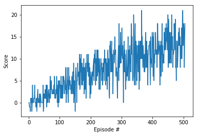

```python
# Instantiate the agent
agent = Agent(state_size=state_size, action_size=action_size, seed=0)

# Train the DQN agent
scores = train_dqn(agent)

# Plot the scores
plot_scores(scores)
```

#### 10 Trials on Hyperparameter Tuning

```python
from dqn_agent import Agent
```

```
Episode 100	Average score over the last 100 episodes: 2.90
Episode 200	Average score over the last 100 episodes: 7.86
Episode 300	Average score over the last 100 episodes: 10.93
Episode 377	Average score over the last 100 episodes: 13.10
Environment solved in 377 episodes!	Average score over the last 100 episodes: 13.10
```

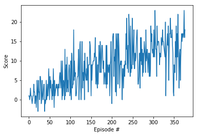

```python
# Try an epsilon decay of 0.95
# Buffer size of 1e5 and learning rate of 5e-4
agent = Agent(state_size=state_size, action_size=action_size, seed=0)
scores = train_dqn(agent, eps_decay=0.95)
plot_scores(scores)
```

```
Episode 100	Average score over the last 100 episodes: 4.00
Episode 200	Average score over the last 100 episodes: 10.42
Episode 287	Average score over the last 100 episodes: 13.00
Environment solved in 287 episodes!	Average score over the last 100 episodes: 13.00
```

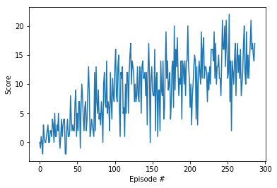

```python
# Increase buffer size to 1e6 and decrease learning rate to 25e-5
# With an epsilon decay of 0.95
agent = Agent(state_size=state_size, action_size=action_size, seed=0)
scores = train_dqn(agent, eps_decay=0.95)
plot_scores(scores)
```

```
Episode 100	Average score over the last 100 episodes: 2.27
Episode 200	Average score over the last 100 episodes: 7.71
Episode 300	Average score over the last 100 episodes: 11.02
Episode 352	Average score over the last 100 episodes: 13.00
Environment solved in 352 episodes!	Average score over the last 100 episodes: 13.00
```

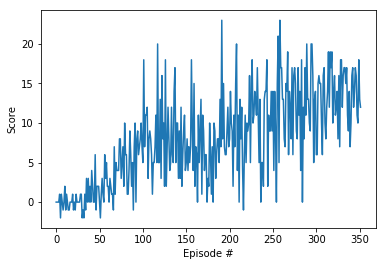

```python
# Increase number of hidden units in two hidden layers to 128 units each
# With buffer size of 1e6 and learning rate of 25e-5
# With an epsilon decay of 0.95
agent = Agent(state_size=state_size, action_size=action_size, seed=0)
scores = train_dqn(agent, eps_decay=0.95)
plot_scores(scores)
```

```
Episode 100	Average score over the last 100 episodes: 2.77
Episode 200	Average score over the last 100 episodes: 9.61
Episode 300	Average score over the last 100 episodes: 12.40
Episode 361	Average score over the last 100 episodes: 13.07
Environment solved in 361 episodes!	Average score over the last 100 episodes: 13.07
```

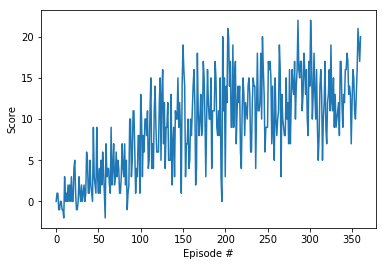

```python
# Decrease number of hidden units in two hidden layers to 40 units each
# With buffer size of 1e6 and learning rate of 25e-5
# With an epsilon decay of 0.95
agent = Agent(state_size=state_size, action_size=action_size, seed=0)
scores = train_dqn(agent, eps_decay=0.95)
plot_scores(scores)
```

```
Episode 100	Average score over the last 100 episodes: 3.05
Episode 200	Average score over the last 100 episodes: 8.67
Episode 300	Average score over the last 100 episodes: 11.42
Episode 399	Average score over the last 100 episodes: 13.01
Environment solved in 399 episodes!	Average score over the last 100 episodes: 13.01
```

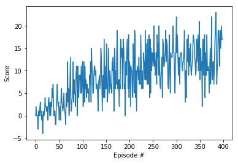

```python
# Increase learning rate from 25e-5 to 1e-3
# With number of hidden units in two hidden layers to 64 units each
# With buffer size of 1e6
# With an epsilon decay of 0.95
agent = Agent(state_size=state_size, action_size=action_size, seed=0)
scores = train_dqn(agent, eps_decay=0.95)
plot_scores(scores)
```

```
Episode 100	Average score over the last 100 episodes: 2.87
Episode 200	Average score over the last 100 episodes: 6.00
Episode 300	Average score over the last 100 episodes: 12.94
Episode 301	Average score over the last 100 episodes: 13.11
Environment solved in 301 episodes!	Average score over the last 100 episodes: 13.11
```

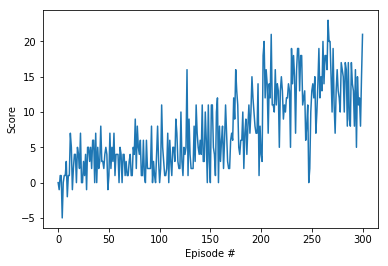

```python
# Decrease epsilon decay from 0.95 to 0.85
# With number of hidden units in two hidden layers to 64 units each
# With buffer size of 1e6 and learning rate of 25e-5
agent = Agent(state_size=state_size, action_size=action_size, seed=0)
scores = train_dqn(agent, eps_decay=0.85)
plot_scores(scores)
```

[output not shown]

```python
# Note: Interrupted after 893 episodes -- the agent does not appear to learn well

# Decrease gamma from 0.99 to 0.8
# With number of hidden units in two hidden layers to 64 units each
# With buffer size of 1e6 and learning rate of 25e-5
# With an epsilon decay of 0.95
agent = Agent(state_size=state_size, action_size=action_size, seed=0)
scores = train_dqn(agent, eps_decay=0.95)
plot_scores(scores)

"""
Episode 100 Average score over the last 100 episodes: 3.36
Episode 200 Average score over the last 100 episodes: 4.61
Episode 300 Average score over the last 100 episodes: 6.41
Episode 400 Average score over the last 100 episodes: 9.58
Episode 500 Average score over the last 100 episodes: 9.771
Episode 600 Average score over the last 100 episodes: 10.79
Episode 700 Average score over the last 100 episodes: 11.50
Episode 800 Average score over the last 100 episodes: 12.08
Episode 893 Average score over the last 100 episodes: 10.56
"""
```

```
Episode 100	Average score over the last 100 episodes: 4.95
Episode 200	Average score over the last 100 episodes: 10.34
Episode 289	Average score over the last 100 episodes: 13.11
Environment solved in 289 episodes!	Average score over the last 100 episodes: 13.11
```

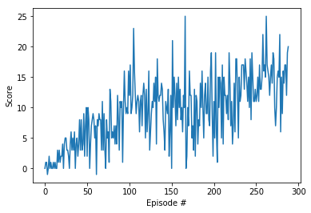

```python
# Increase gamma from 0.99 to 0.999
# With number of hidden units in two hidden layers to 64 units each
# With buffer size of 1e6 and learning rate of 25e-5
# With an epsilon decay of 0.95
agent = Agent(state_size=state_size, action_size=action_size, seed=0)
scores = train_dqn(agent, eps_decay=0.95)
plot_scores(scores)
```

```
Episode 100	Average score over the last 100 episodes: 3.73
Episode 200	Average score over the last 100 episodes: 8.25
Episode 300	Average score over the last 100 episodes: 12.14
Episode 400	Average score over the last 100 episodes: 12.41
Episode 488	Average score over the last 100 episodes: 13.00
Environment solved in 488 episodes!	Average score over the last 100 episodes: 13.00
```

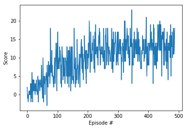

```python
# Increase ending epsilon from 0.01 to 0.1
# With gamma of 0.99
# With number of hidden units in two hidden layers to 64 units each
# With buffer size of 1e6 and learning rate of 25e-5
# With an epsilon decay of 0.95
agent = Agent(state_size=state_size, action_size=action_size, seed=0)
scores = train_dqn(agent, eps_end=0.1, eps_decay=0.95)
plot_scores(scores)
```

```
Episode 100	Average score over the last 100 episodes: 2.91
Episode 200	Average score over the last 100 episodes: 7.00
Episode 286	Average score over the last 100 episodes: 13.06
Environment solved in 286 episodes!	Average score over the last 100 episodes: 13.06
```

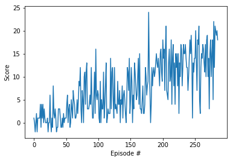

```python
# Decrease ending epsilon from 0.01 to 1e-3
# With gamma of 0.99
# With number of hidden units in two hidden layers to 64 units each
# With buffer size of 1e6 and learning rate of 25e-5
# With an epsilon decay of 0.95
agent = Agent(state_size=state_size, action_size=action_size, seed=0)
scores = train_dqn(agent, eps_end=1e-3, eps_decay=0.95)
plot_scores(scores)
```

#### Final Run

```python
from dqn_agent import Agent
```

```python
num_episodes = []

# Train the final DQN agent for 10 trials
for i in range(10):
    # Ending epsilon of 1e-3
    # With gamma of 0.99
    # With number of hidden units in two hidden layers to 64 units each
    # With buffer size of 1e6 and learning rate of 25e-5
    # With an epsilon decay of 0.95
    agent = Agent(state_size=state_size, action_size=action_size, seed=0)
    scores = train_dqn(agent, eps_end=1e-3, eps_decay=0.95)

    # Save the number of episodes required to solve the environment
    num_episodes.append(len(scores))
```

```
Episode 100	Average score over the last 100 episodes: 5.00
Episode 200	Average score over the last 100 episodes: 8.66
Episode 268	Average score over the last 100 episodes: 13.08
Environment solved in 268 episodes!	Average score over the last 100 episodes: 13.08
Episode 100	Average score over the last 100 episodes: 4.18
Episode 200	Average score over the last 100 episodes: 10.22
Episode 261	Average score over the last 100 episodes: 13.01
Environment solved in 261 episodes!	Average score over the last 100 episodes: 13.01
Episode 100	Average score over the last 100 episodes: 3.83
Episode 200	Average score over the last 100 episodes: 7.29
Episode 289	Average score over the last 100 episodes: 13.02
Environment solved in 289 episodes!	Average score over the last 100 episodes: 13.02
Episode 100	Average score over the last 100 episodes: 3.08
Episode 200	Average score over the last 100 episodes: 6.49
Episode 300	Average score over the last 100 episodes: 11.67
Episode 318	Average score over the last 100 episodes: 13.09
Environment solved in 318 episodes!	Average score over the last 100 episodes: 13.09
Episode 100	Average score over the last 100 episodes: 3.36
Episode 200	Average score over the last 100 episodes: 9.13
Episode 289	Average score over the last 100 episodes: 13.05
Environment solved in 289 episodes!	Average score over the last 100 episodes: 13.05
Episode 100	Average score over the last 100 episodes: 4.13
Episode 200	Average score over the last 100 episodes: 9.08
Episode 276	Average score over the last 100 episodes: 13.10
Environment solved in 276 episodes!	Average score over the last 100 episodes: 13.10
Episode 100	Average score over the last 100 episodes: 4.15
Episode 200	Average score over the last 100 episodes: 9.12
Episode 300	Average score over the last 100 episodes: 11.73
Episode 329	Average score over the last 100 episodes: 13.04
Environment solved in 329 episodes!	Average score over the last 100 episodes: 13.04
Episode 100	Average score over the last 100 episodes: 3.86
Episode 200	Average score over the last 100 episodes: 8.84
Episode 300	Average score over the last 100 episodes: 11.97
Episode 337	Average score over the last 100 episodes: 13.09
Environment solved in 337 episodes!	Average score over the last 100 episodes: 13.09
Episode 100	Average score over the last 100 episodes: 3.15
Episode 200	Average score over the last 100 episodes: 8.24
Episode 300	Average score over the last 100 episodes: 12.34
Episode 318	Average score over the last 100 episodes: 13.13
Environment solved in 318 episodes!	Average score over the last 100 episodes: 13.13
Episode 100	Average score over the last 100 episodes: 4.85
Episode 200	Average score over the last 100 episodes: 8.79
Episode 275	Average score over the last 100 episodes: 13.06
Environment solved in 275 episodes!	Average score over the last 100 episodes: 13.06
```

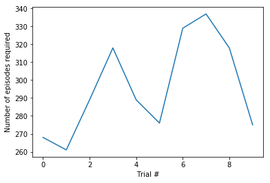

```python
# Plot the number of episodes required per trial
fig = plt.figure()
ax = fig.add_subplot(111)
plt.plot(np.arange(len(num_episodes)), num_episodes)
plt.ylabel('Number of episodes required')
plt.xlabel('Trial #')
plt.show()
```

```python
# Compute the average and median number of episodes
mean_num_episodes = np.mean(num_episodes)
median_num_episodes = np.median(num_episodes)
print(f'Average number of episodes required to solve the environment: {mean_num_episodes}')
print(f'Median number of episodes required to solve the environment: {median_num_episodes}')
```

```
Average number of episodes required to solve the environment: 296.0
Median number of episodes required to solve the environment: 289.0
```

#### Run the final model one last time to save the model's learned parameters

```
Episode 100	Average score over the last 100 episodes: 3.89
Episode 200	Average score over the last 100 episodes: 7.76
Episode 291	Average score over the last 100 episodes: 13.01
Environment solved in 291 episodes!	Average score over the last 100 episodes: 13.01
```

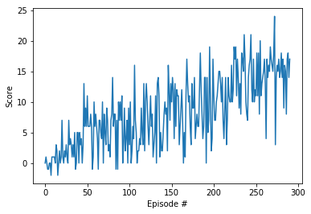

```python
# Ending epsilon of 1e-3
# With gamma of 0.99
# With number of hidden units in two hidden layers to 64 units each
# With buffer size of 1e6 and learning rate of 25e-5
# With an epsilon decay of 0.95
agent = Agent(state_size=state_size, action_size=action_size, seed=0)
scores = train_dqn(agent, eps_end=1e-3, eps_decay=0.95, save_file='final_model_weights.pth')
plot_scores(scores)
```